# PlotMicrobiome analysis with AI report

## PlotMicrobiome analysis report with AI assistance

The analysis of microbiome data was performed with PlotMicrobiome (https://github.com/ssun6/plotmicrobiome).

The interpretation of the data was generated with AI models mistral.

AI can make mistakes, please review all interpretations and conclusions critically before drawing scientific inferences.

### PCoA analysis by rural_urban_status

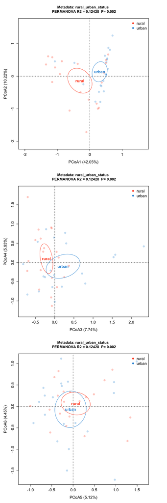

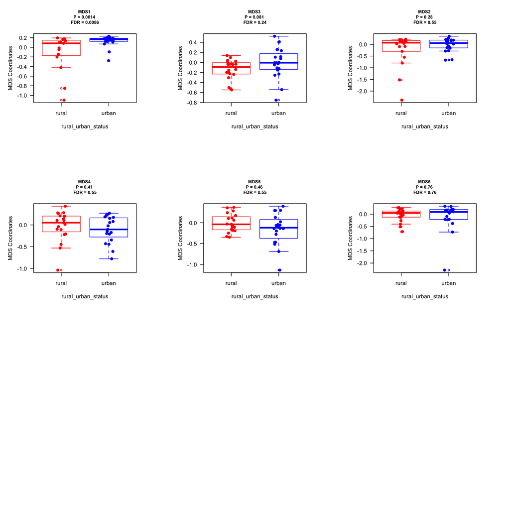

## AI-generated Summary

The PERMANOVA test results indicate a significant difference (P-value = 0.002) between the samples, with an explained variance (R2) of 12.4%. The Multidimensional Scaling (MDS) analysis shows that the separation of samples is most pronounced on MDS1 axis, where FDR (False Discovery Rate) is below 0.1 (FDR = 0.00860972722461336), making it statistically significant. The urban group appears to be enriched along this axis, suggesting that the rural-urban status might play a key role in the observed variation among samples. However, no other MDS axes were found to be significantly separated based on the FDR threshold of 0.1. This suggests that the urban versus rural distinction might be the main driver of differences between the samples, while other factors may have less impact on the observed patterns.